# BMIN503/EPID600 Project Template

Mark Potter

### Overview

> This project will examine the possible relationship between olfactory funciton, hand-grip strength, and cognition. The data will be derived from the National Health and Nutrition Examination Survey (NHANES) administered in 2013-2014. Thank you for your help Dr. Richard Doty, Dr. Fran Shofer, and Tom McKeon, MPH.

### Introduction

> Smell dysfunction is an early biomarker of neurodegenerative diseases such as Parkinson’s and Alheimer’s. It is also very closely associated with measures of cognition such as the Montreal Cognitive Assessment Test and the Mini-Mental Status Examination. There is also a growing area of literature examing grip-strength and it’s close relationship between cognitive function. This project will be exploratory and examine if a relationship exists between olfaction, grip-strength, and cognitive scores. In 2013-2014 the NHANES added a smell assessment test to their extensive battery of tests.This test was a 8-item scratch and sniff test developed by Sensonics International (Haddonfield, NJ). There are numerious publications examining the olfactory ability and various tests and assesments administered during the NHANEs such as cognition, cardiometabolic function, and diabetes. Decreased cognitive dysfunction is associated with a decrease in grip-strength. It is theorized that neuro-decline in regions of cognition are close in proximity to motor areas and could explain the decline. There are many causes of decline in grip-strength such such as frailty and its related mechanims. If a relationship between grip-strength, cognition, and olfaction exists, a combination of the tests could serve as a cheap method of measuring brain-health.

> Exploring olfaction, grip-strength, and cognition crosses many disciplines. While olfaction is largely studied in clinical settings within Otorhinolaryngology departments, neurodegenerative diseases are explored by neurologists and movement disorder specialists. Since smell loss can occur before any motor symptoms arise in diseases like Parkinson’s it is an important biomarker to understand. It is unknown why the olfactory system is such an early biomarker but it is theorized that Acetylcholine (ACh) may play a major role. In diseases such as Myasthenia Gravis, which is a motor-endplate disorder affecting the neuromuscular junction (NMJ) and ACh, suprisingly has demonstrable smell dysfunction. This suggests that there may be central cholinergic dysfunction. The relationship between cognition and ACh is widely explored and decreases in cognition are associated with ACh decline. In a similar sense, grip-strength requires release of ACh in the NMJ to fire the muscle contraction. The exploratory examination of these relationships may lead to more specific work measuring ACh and olfaction.

### Methods

> The data used will be from separate NHANES 2013-2014 examinations and surveys. The datasets will be joined by the patient identifier (SEQN).

```r
library(foreign)
library(dplyr)
library(tidyr)
```

```r
library(ggplot2)
library(modelsummary)
library(survey)
#Download Demographics
download.file("https://wwwn.cdc.gov/nchs/nhanes/2013-2014/DEMO_H.XPT", tf <- tempfile(), mode="wb")
DEMO <- foreign::read.xport(tf)
#Download Cognitive Functioning
download.file("https://wwwn.cdc.gov/nchs/nhanes/2013-2014/CFQ_H.XPT", tf <- tempfile(), mode="wb")
COG <- foreign::read.xport(tf)
#Download Smell and Taste Exam
download.file("https://wwwn.cdc.gov/nchs/nhanes/2013-2014/CSX_H.XPT", tf <- tempfile(), mode="wb")
ST <- foreign::read.xport(tf)
#Download Grip Strength
download.file("https://wwwn.cdc.gov/nchs/nhanes/2013-2014/MGX_H.XPT", tf <- tempfile(), mode="wb")
GS <- foreign::read.xport(tf)

STDEMO <- inner_join(ST, DEMO, by = "SEQN")
COGGS <- inner_join(GS, COG, by = "SEQN")
COMBINED <- inner_join(STDEMO, COGGS, by = "SEQN")
```

```r
COMBINED <- COMBINED %>%
            rename(Chocolate = CSXCHOOD, Strawberry = CSXSBOD, Smoke = CSXSMKOD, Leather = CSXLEAOD,
                   Soap = CSXSOAOD, Grape = CSXGRAOD, Onion = CSXONOD, NaturalGas = CSXNGSOD, GripStrength = MGDCGSZ,
                   DigitSymbol = CFDDS, gender = RIAGENDR, age = RIDAGEYR,
                   race = RIDRETH1) %>%
            mutate(gender = factor(gender, levels = c(1, 2), labels = c("male", "female"))) %>%
            mutate(race = factor(race, levels = c(3, 1, 2, 4, 5),
                                 labels = c("White", "MexicanAmerican", "Hispanic", "Black", "other"))) %>%
            filter(!is.na(Chocolate)) %>% #Need to remove NA responses as the test is designed with forced choice questioning no.
            filter(!is.na(Strawberry)) %>%
            filter(!is.na(Smoke)) %>%
            filter(!is.na(Leather)) %>%
            filter(!is.na(Soap)) %>%
            filter(!is.na(Grape)) %>%
            filter(!is.na(Onion)) %>%
            filter(!is.na(NaturalGas)) %>%
            filter(!is.na(GripStrength)) %>%
            filter(!is.na(DigitSymbol))


#Filter Correct Responses
COMBINED$ChocolateCorrect <- COMBINED$Chocolate == 2  # Response 2 Was "correct" for Chocolate
          COMBINED$ChocolateCorrect<- as.numeric(as.logical(COMBINED$ChocolateCorrect))
COMBINED$StrawberryCorrect <- COMBINED$Strawberry == 1  # Response 1 Was "correct" for Strawberry
          COMBINED$StrawberryCorrect<- as.numeric(as.logical(COMBINED$StrawberryCorrect))
COMBINED$SmokeCorrect <- COMBINED$Smoke == 3  # Response 3 Was "correct" for Smoke
          COMBINED$SmokeCorrect<- as.numeric(as.logical(COMBINED$SmokeCorrect))
COMBINED$LeatherCorrect <- COMBINED$Leather == 3  # Response 3 Was "correct" for Leather
          COMBINED$LeatherCorrect<- as.numeric(as.logical(COMBINED$LeatherCorrect))
COMBINED$SoapCorrect <- COMBINED$Soap == 1  # Response 1 Was "correct" for NaturalGas
          COMBINED$SoapCorrect<- as.numeric(as.logical(COMBINED$SoapCorrect))
COMBINED$GrapeCorrect <- COMBINED$Grape == 2  # Response 2 Was "correct" for Grape
          COMBINED$GrapeCorrect<- as.numeric(as.logical(COMBINED$GrapeCorrect))
COMBINED$OnionCorrect <- COMBINED$Onion == 3  # Response 3 Was "correct" for Onion
          COMBINED$OnionCorrect<- as.numeric(as.logical(COMBINED$OnionCorrect))
COMBINED$NaturalGasCorrect <- COMBINED$NaturalGas == 4  # Response 4 Was "correct" for NaturalGas
          COMBINED$NaturalGasCorrect<- as.numeric(as.logical(COMBINED$NaturalGasCorrect))
#Calculate Total Smell Identification Score
COMBINED$TotalSIT <- rowSums(COMBINED[,c(133:140)])

#calculate Normal Olfaction vs. Demonstrable Dysfunction
COMBINED$OlfactoryAbility <- COMBINED$TotalSIT >= 6  # 6 or Above considered normal based on literature
     COMBINED$OlfactoryAbility<- as.factor(as.logical(COMBINED$OlfactoryAbility))
levels(COMBINED$OlfactoryAbility) <- c('Dysfunction', 'Normosmic')
```

### Results

> After cleaning the data, there were a total of 1395 subjects who completed all of the testing. A total of 679 were Male and 716 Female. With regards to race, 52% reported their race as “White”, 10% “Mexican American”, 8% “Hispanic”, 21% “Black”, and 9% “Other”. A total of 1075 were normosmic and 320 had olfactory dysfunction. Age was not normally distributed as subjects aged 80 years and older were all noted as 80 in the results, therefore the median age was 69 years old. The most common smell identification score was a 7/8. The mean combined grip-strength was 61 lbs and the mean Digit Symbol Score was 47.

```r
#Demographics
table(COMBINED$gender)
```

```
##
##   male female
##    679    716
```

```r
table(COMBINED$race)
```

```
##
##           White MexicanAmerican        Hispanic           Black           other
##             725             144             115             293             118
```

```r
table(COMBINED$OlfactoryAbility)
```

```
##
## Dysfunction   Normosmic
##         320        1075
```

```r
median(COMBINED$age)
```

```
## [1] 69
```

```r
table(COMBINED$TotalSIT)
```

```
##
##   0   1   2   3   4   5   6   7   8
##   4   6  25  37  85 163 268 414 393
```

```r
mean(COMBINED$age)
```

```
## [1] 69.44659
```

```r
mean(COMBINED$GripStrength)
```

```
## [1] 61.2271
```

```r
mean(COMBINED$DigitSymbol)
```

```
## [1] 46.87455
```

```r
table(COMBINED$age < 80)
```

```
##
## FALSE  TRUE
##   212  1183
```

> The bar plot below shows the distribution of the total smell identifciation scores. The majority of subjects scored either a 7 or 8 on the test.

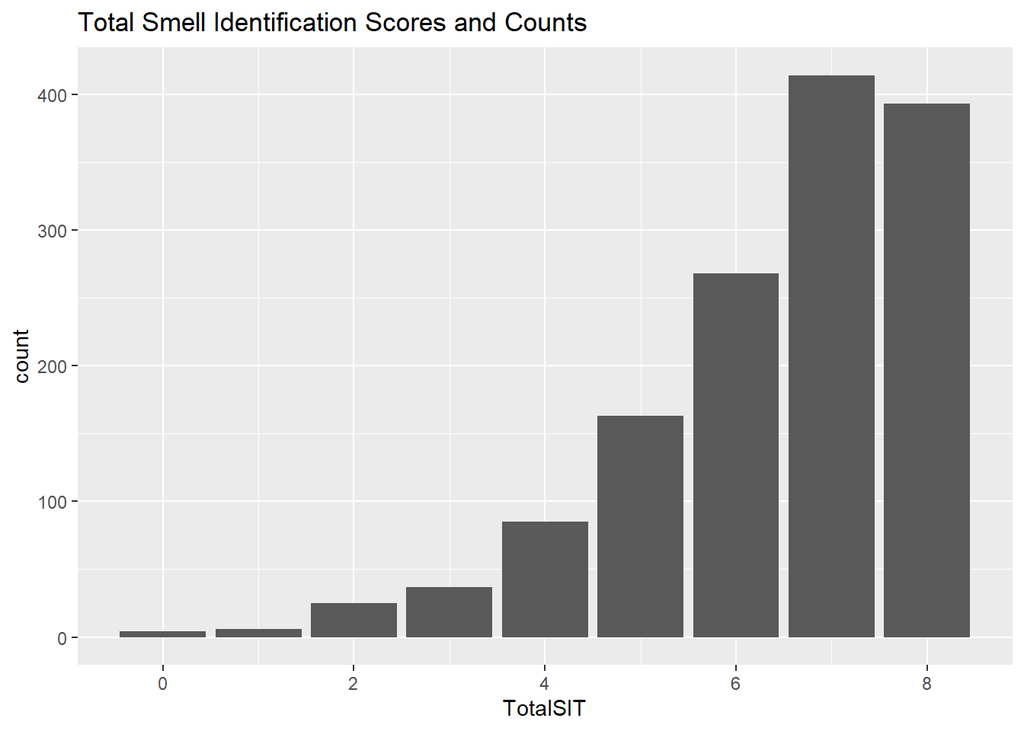

```r
#Total SIT Scores
ggplot(data = COMBINED, aes(x = TotalSIT)) +
    ggtitle("Total Smell Identification Scores and Counts")+
    geom_bar()
```

### >The bar plot below examines olfactory ability by race. The teal color represents normosmic subjects and the salmon color represents those with olfactory dysfunction.

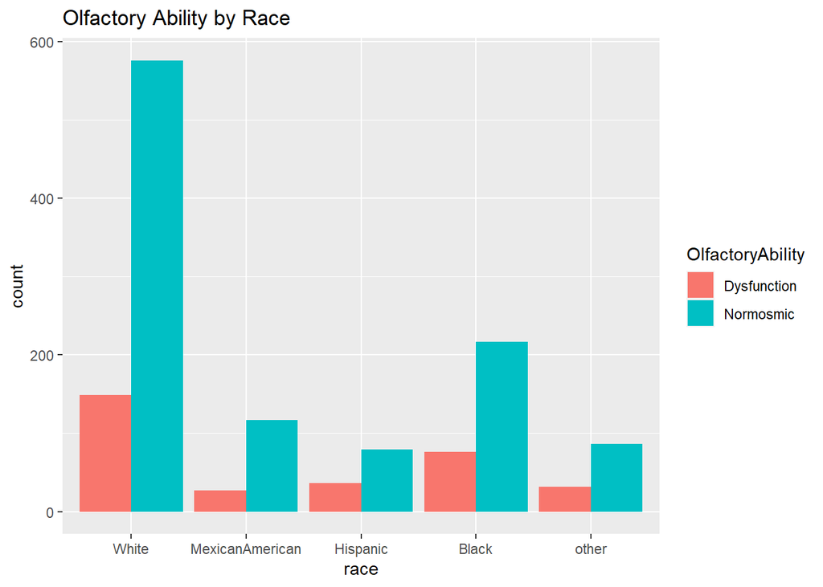

```r
#Race and Olfactory Ability
ggplot(data = COMBINED, aes(x = race, fill = OlfactoryAbility)) +
    ggtitle("Olfactory Ability by Race")+
    geom_bar(position = "dodge")
```

### >The bar graph below examines the olfactory ability by gender. Again, the teal color represents normosmic subjects and the salmon color represents those with olfactory dysfunction. Here we observe, a well established phenomena that female subjects have a better sense of smell than male subjects.

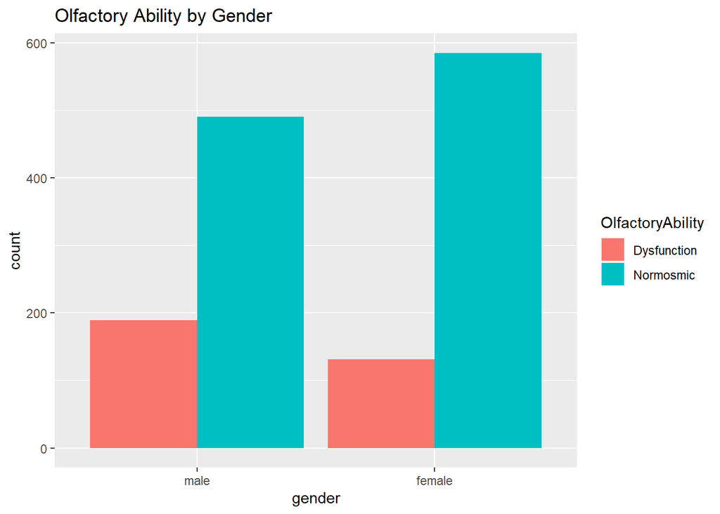

```r
#Gender and Olfactory Ability
ggplot(data = COMBINED, aes(x = gender, fill = OlfactoryAbility)) +
    ggtitle("Olfactory Ability by Gender")+
    geom_bar(position = "dodge")
```

### > The boxplot below shows distribution of ages in the normosmic and dysfunction groups. Please note that this includes the extra cases of 200 individuals who were marked as age 80.

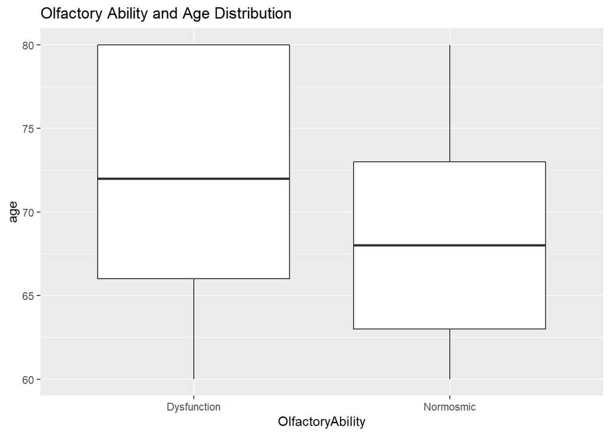

```r
#Plot Age by Olfactory Ability
ggplot(data = COMBINED, aes(x = OlfactoryAbility, y = age)) +
    ggtitle("Olfactory Ability and Age Distribution")+
    geom_boxplot()
```

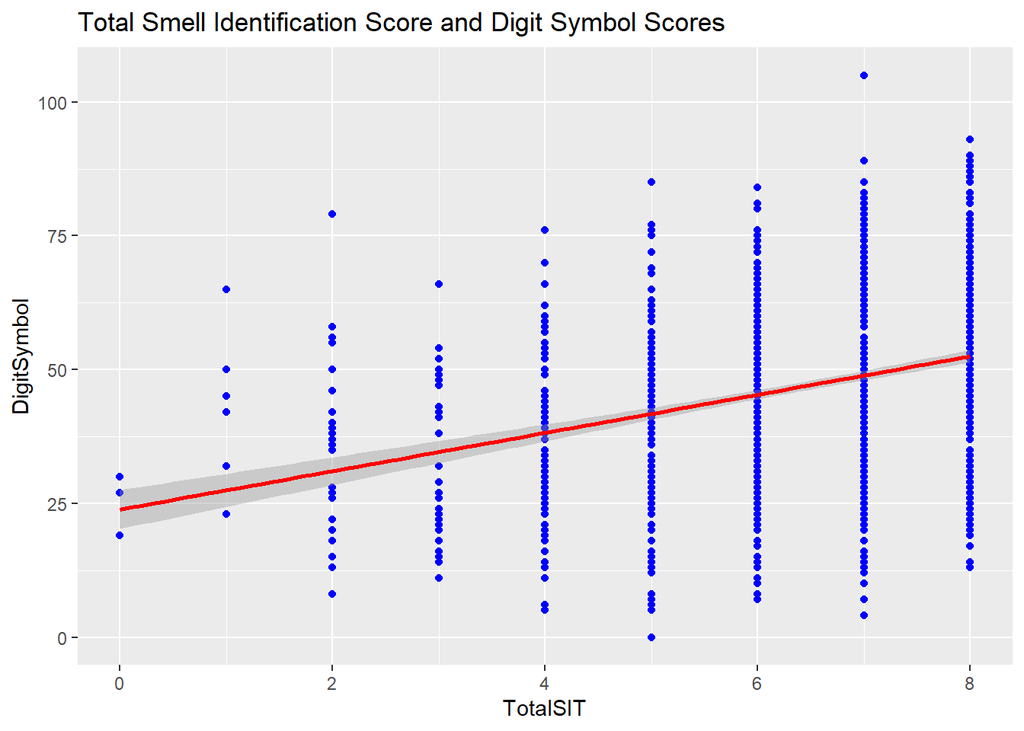

```r
#Exploratory
ggplot(data = COMBINED, aes(x = TotalSIT, y = DigitSymbol)) +
    geom_point(color = "blue") +
    geom_smooth(method = "lm", color = "red")+
    ggtitle("Total Smell Identification Score and Digit Symbol Scores")
```

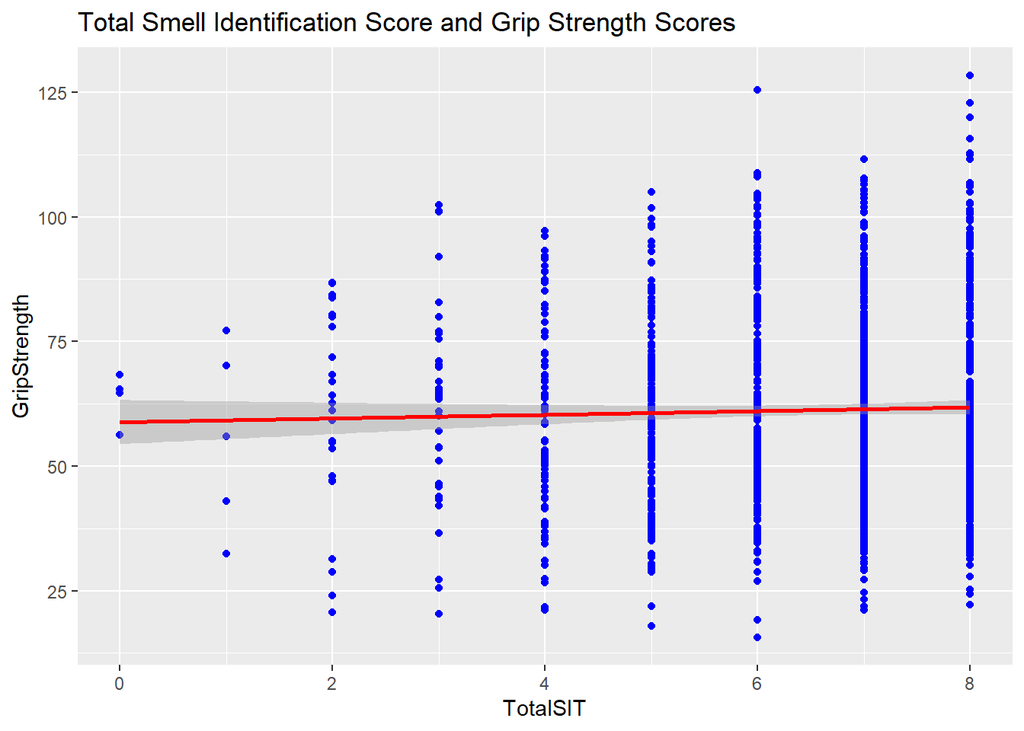

```r
ggplot(data = COMBINED, aes(x = TotalSIT, y = GripStrength)) +
    geom_point(color = "blue") +
    geom_smooth(method = "lm", color = "red")+
    ggtitle("Total Smell Identification Score and Grip Strength Scores")
```

### >Below is the linear regression for the total smell score, digit symbol, grip-strength, gender, age, and race. The results reveal significant associations between all variables exccept for race being Mexican American or Hispanic. The positive association between olfaction and the cognitive (DSST) test is as expected. The negative association between age and olfaction is also expected. After the age of 65 everyone experiences some decline in olfactory dysfunction. Additionally, there was an association between grip-strength and total smell score. While the effects are small based on the odds ratio, there is some sort of association evident.

```r
#Regression
TotalSIT<- summary.lm(lm(TotalSIT ~ DigitSymbol + GripStrength + gender + age +race, data = COMBINED))
print(TotalSIT)
```

```
##
## Call:
## lm(formula = TotalSIT ~ DigitSymbol + GripStrength + gender +
##     age + race, data = COMBINED)
##
## Residuals:
##     Min      1Q  Median      3Q     Max
## -6.0866 -0.7843  0.2524  1.0408  2.7475
##
## Coefficients:
##                      Estimate Std. Error t value Pr(>|t|)
## (Intercept)          7.343145   0.646415  11.360  < 2e-16 ***
## DigitSymbol          0.021697   0.002676   8.108 1.12e-15 ***
## GripStrength         0.006283   0.003130   2.007  0.04493 *
## genderfemale         0.461182   0.116844   3.947 8.31e-05 ***
## age                 -0.035331   0.006884  -5.132 3.27e-07 ***
## raceMexicanAmerican  0.079544   0.138805   0.573  0.56669
## raceHispanic        -0.260725   0.150893  -1.728  0.08423 .
## raceBlack           -0.239359   0.108727  -2.201  0.02787 *
## raceother           -0.388730   0.142972  -2.719  0.00663 **
## ---
## Signif. codes:  0 '***' 0.001 '**' 0.01 '*' 0.05 '.' 0.1 ' ' 1
##
## Residual standard error: 1.417 on 1386 degrees of freedom
## Multiple R-squared:  0.1458, Adjusted R-squared:  0.1409
## F-statistic: 29.57 on 8 and 1386 DF,  p-value: < 2.2e-16
```

```r
exp(coef(TotalSIT)) #Odds ratios.
```

```
##                         Estimate Std. Error      t value Pr(>|t|)
## (Intercept)         1545.5655708   1.908687 8.580168e+04 1.000000
## DigitSymbol            1.0219338   1.002680 3.320911e+03 1.000000
## GripStrength           1.0063030   1.003135 7.442107e+00 1.045952
## genderfemale           1.5859481   1.123944 5.177876e+01 1.000083
## age                    0.9652861   1.006908 5.902358e-03 1.000000
## raceMexicanAmerican    1.0827936   1.148901 1.773692e+00 1.762432
## raceHispanic           0.7704927   1.162872 1.776605e-01 1.087882
## raceBlack              0.7871323   1.114857 1.106398e-01 1.028259
## raceother              0.6779174   1.153697 6.594553e-02 1.006653
```

### Discussion/Conclusion

> There is an observed association between grip-strength, cognition, and olfactory ability. Given the broad associations observed, the smell test, grip-strength, and DSST likely reflect overall health. There are many limitions with this study as it simply an exploratory report. For instance, the broad associations seen may simply reflect the overal health of the population and the tests examined reflect that. More variables should be added to the model as well to futher explore and understand what might be going on. Next steps would be to include the additional cognitive tests collected in the study. It would also be interesting to observe any differences between handedness by examining dominant vs. non-dominant hands. Additionally, machine learning could be utilized to examine if the failure to smell certain odors could serve as a predictor of cognitive decline.